# Explore One Variable EDA – Facebook Pseudo Data

### Pseudo-Facebook User Data

```r
getwd()
```

```
## [1] "/Users/freena/Desktop/R_Programming"
```

```r
list.files()
```

```
##  [1] "Diamonds.R"
##  [2] "Explore_One_Variable_pseudo_facebook.rmd"
##  [3] "lesson2"
##  [4] "lesson3"
##  [5] "lesson4"
##  [6] "lesson5"
##  [7] "lesson6"
##  [8] "pseudo_facebook.tsv"
##  [9] "R_Programming_Tutorial_Practice.R"
## [10] "README.md"
## [11] "Reddit_Data_EDA.R"
## [12] "reddit.csv"
## [13] "Reddit.R"
```

```r
pf <- read.csv('pseudo_facebook.tsv', sep = '\t')
names(pf)
```

```
##  [1] "userid"                "age"
##  [3] "dob_day"               "dob_year"
##  [5] "dob_month"             "gender"
##  [7] "tenure"                "friend_count"
##  [9] "friendships_initiated" "likes"
## [11] "likes_received"        "mobile_likes"
## [13] "mobile_likes_received" "www_likes"
## [15] "www_likes_received"
```

### Histogram of Users’ Birthdays

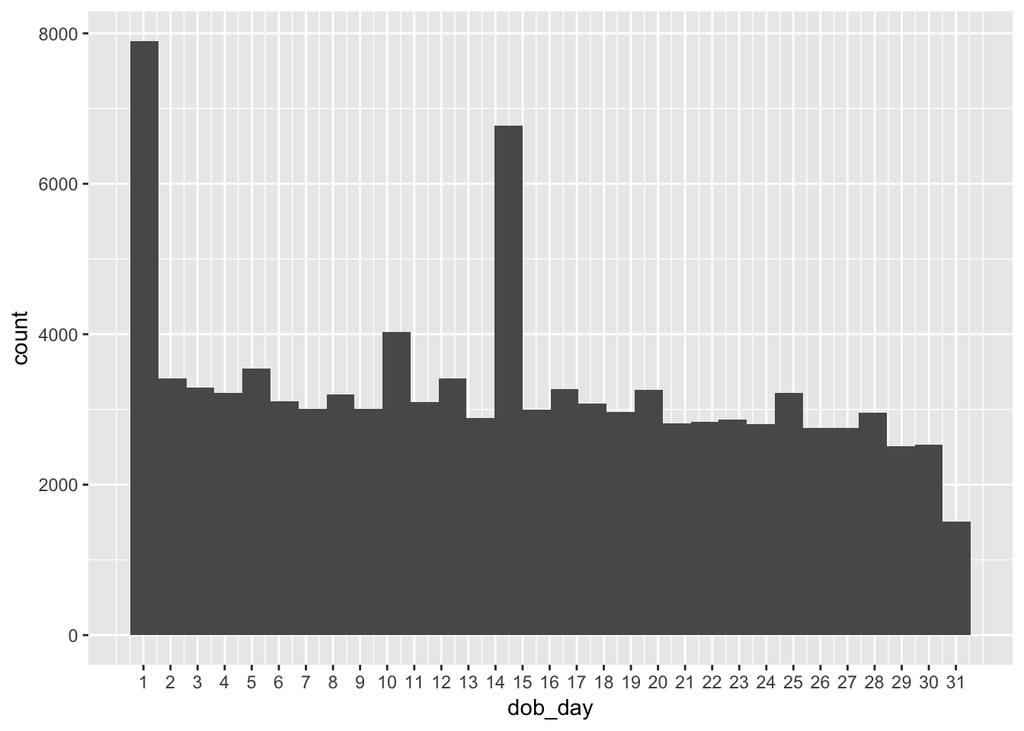

```r
library(ggplot2)
qplot(x = dob_day, data = pf) +
  scale_x_continuous(breaks=1:31)
```

### Faceting

- facet_wrap(~variable) facet_grid(vertical ~ horizontal)

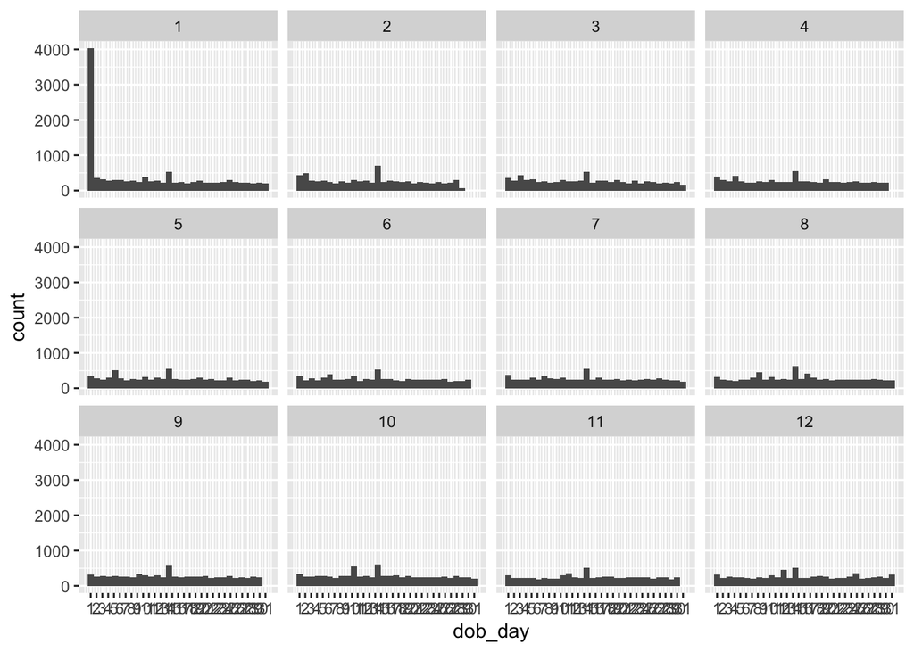

```r
qplot(x = dob_day, data = pf) +
  scale_x_continuous(breaks=1:31) +
  facet_wrap(~dob_month, ncol = 4)
```

#### Take another look at our plot.

There’s almost 4,000 users in Jan 1 (huge spike), which means lots of people choose the first one in the drop down menus OR protect the privacy then choose the first one. ***

### Friend Count

```r
qplot(x = friend_count, data = pf)
# optional 2
ggplot(aes(x = friend_count), data = pf) +
  geom_histogram()
```

[output not shown]

### Limiting the Axes

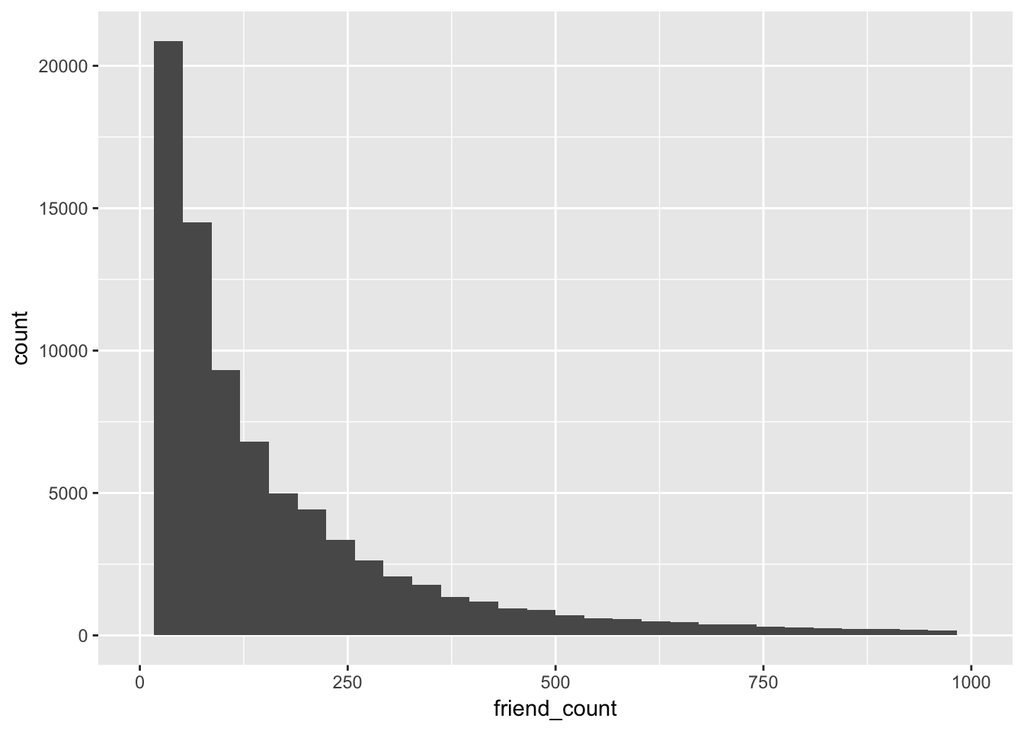

```r
qplot(x = friend_count, data = pf, xlim = c(0, 1000))
```

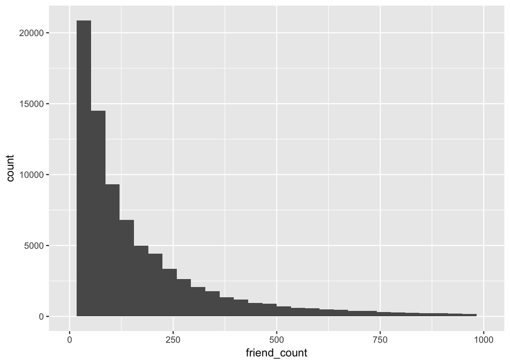

```r
# Another option:
qplot(x = friend_count, data = pf) +
  scale_x_continuous(limits = c(0, 1000))
```

### Adjusting the Bin Width

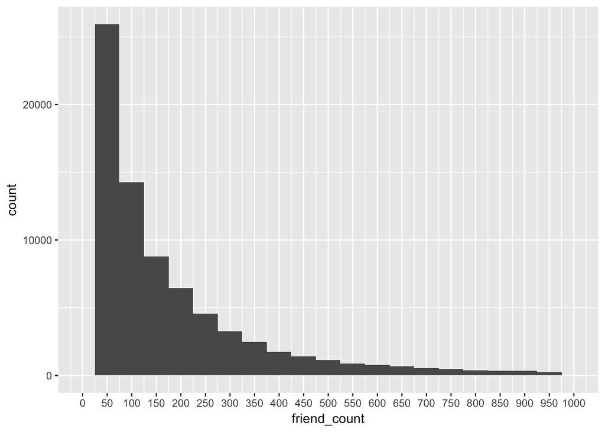

```r
qplot(x = friend_count, data = pf, binwidth = 50) +
  scale_x_continuous(limits = c(0, 1000), breaks = seq(0,1000,50))
```

- Many users have less than 25 friends, those are probably new.

### Faceting Friend Count

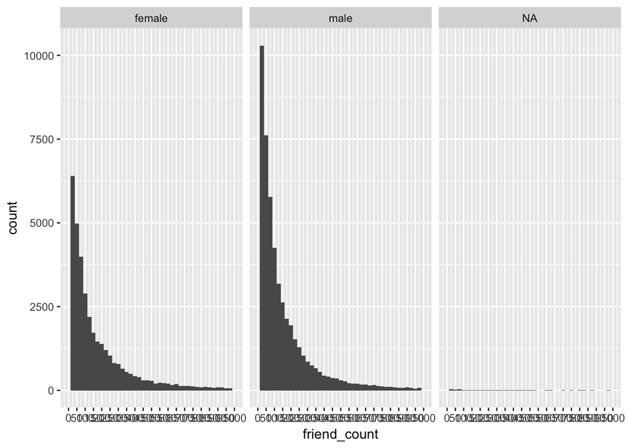

```r
# Create a facet the histogram by gender?
qplot(x = friend_count, data = pf, binwidth = 25) +
  scale_x_continuous(limits = c(0, 1000), breaks = seq(0, 1000, 50)) +
facet_wrap(~gender)
```

### Omitting NA Values

```r
# Option 1: should be careful when using na.omit wrapper since it might ignoring some users that are labeled as male/female but do have
#           some NA values in other colomns such as friend_count.
qplot(x = friend_count, data = na.omit(pf), binwidth = 10) +
  scale_x_continuous(limits = c(0, 1000), breaks = seq(0, 1000, 50)) +
facet_wrap(~gender)
# Option 2:
qplot(x = friend_count, data = subset(pf, !is.na(gender)), binwidth = 10) +
  scale_x_continuous(limits = c(0, 1000), breaks = seq(0, 1000, 50)) +
facet_wrap(~gender)
```

[output not shown]

### Statistics ‘by’ Gender

- Who has more friends? Male or Female?

```r
table(pf$gender)
```

```
##
## female   male
##  40254  58574
```

```r
by(pf$friend_count, pf$gender, summary)
```

```
## pf$gender: female
##    Min. 1st Qu.  Median    Mean 3rd Qu.    Max.
##       0      37      96     242     244    4923
## --------------------------------------------------------
## pf$gender: male
##    Min. 1st Qu.  Median    Mean 3rd Qu.    Max.
##       0      27      74     165     182    4917
```

### Tenure

- the ‘color’ determines the color outline of objects in a plot
- the ‘fill’ determines the color of the area inside objects in a plot

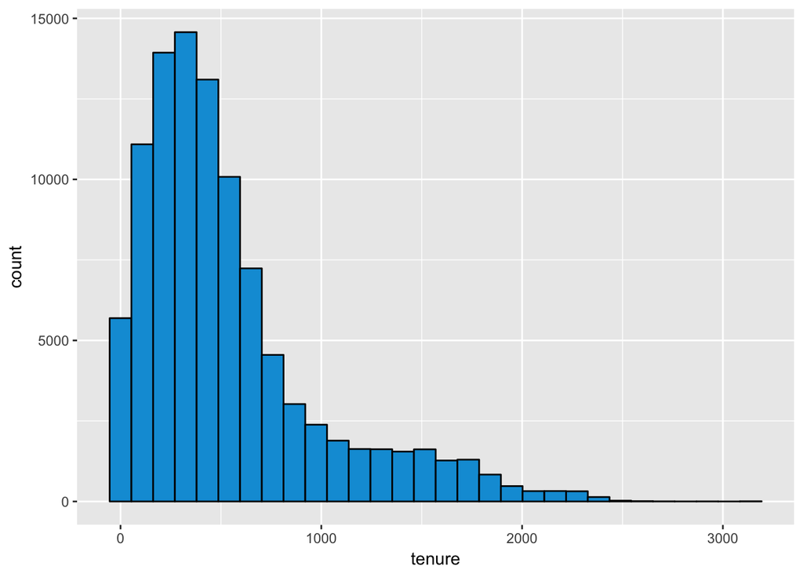

```r
qplot(x = tenure, data = pf,
      color = I('black'), fill = I('#099DD9'))
```

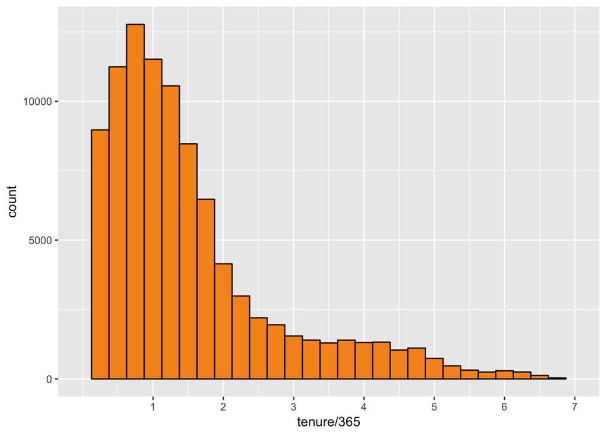

```r
# measure tenure by years rather than days
qplot(x = tenure/365, data = pf, binwidth = .25,
      color = I('black'), fill = I('#F79420')) +
  scale_x_continuous(breaks = seq(1,7,1), limits = c(0,7))
```

### Labeling Plots

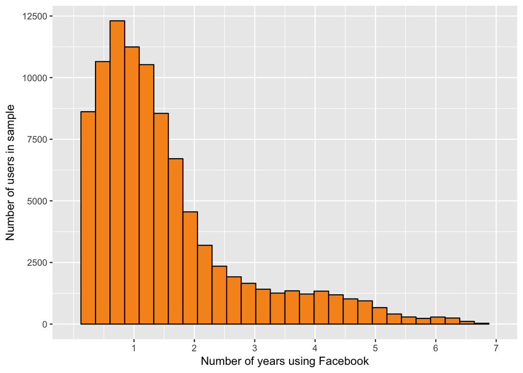

```r
library(ggplot2)
qplot(x = tenure/365, data = pf,
      xlab = 'Number of years using Facebook',
      ylab = 'Number of users in sample',
      color = I('black'), fill = I('#F79420')) +
  scale_x_continuous(breaks = seq(1,7,1), limits = c(0,7))
```

### User Ages

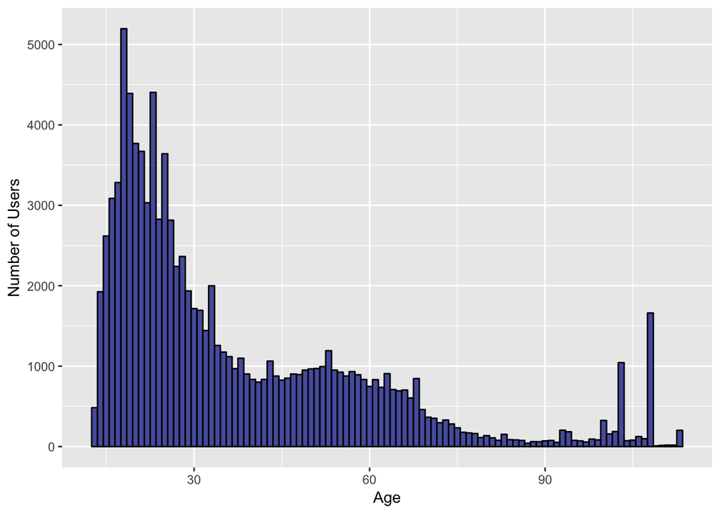

```r
qplot(x = age, data = pf, binwidth = 1,
      xlab = 'Age',
      ylab = 'Number of Users',
      color = I('black'), fill = I('#5760AB'))
```

### Transforming Data

- engagement variables – all have very long tails. In statistics, the data is over dispersed. Thus, we need to transform these values to short the tails.

```r
qplot(x = friend_count, data = pf)
summary(pf$friend_count)
```

```
##    Min. 1st Qu.  Median    Mean 3rd Qu.    Max.
##     0.0    31.0    82.0   196.4   206.0  4923.0
```

```r
# transform the variable by taking the log (natural log/ log base2/log base10)

summary(log10(pf$friend_count + 1))  # add 1 to avoid 0 to be negative infinity in log
```

```
##    Min. 1st Qu.  Median    Mean 3rd Qu.    Max.
##   0.000   1.505   1.919   1.868   2.316   3.692
```

```r
# # transform the variable by taking the sqrt
summary(sqrt(pf$friend_count))
```

```
##    Min. 1st Qu.  Median    Mean 3rd Qu.    Max.
##   0.000   5.568   9.055  11.088  14.353  70.164
```

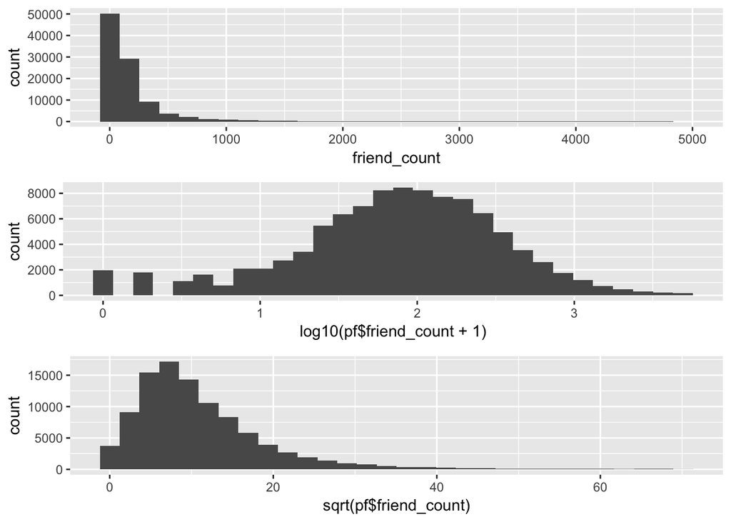

```r
# create multiple plots on one page by using scales
library(gridExtra)

# Option 1:
p1 <- qplot(x = friend_count, data = (pf))
p2 <- qplot(x = log10(pf$friend_count + 1), data = pf)
p3 <- qplot(x = sqrt(pf$friend_count), data = pf)
grid.arrange(p1,p2,p3, ncol=1)
```

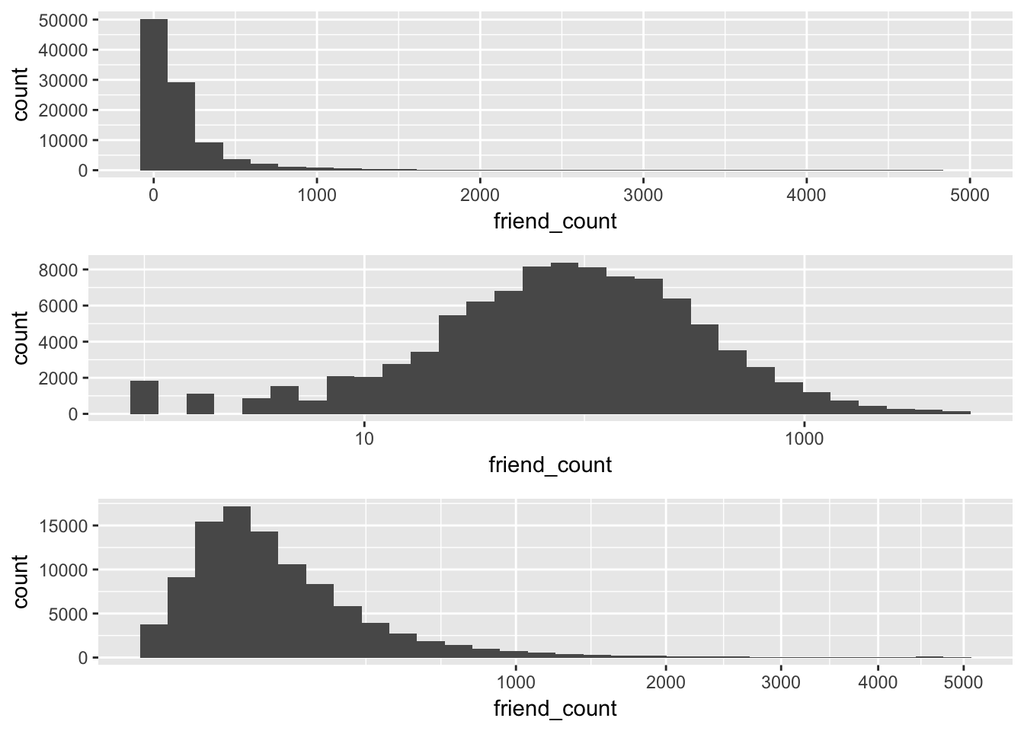

```r
# Option 2:
p1 <- ggplot(aes(x = friend_count), data = pf) + geom_histogram()
p2 <- p1 + scale_x_log10()
p3 <- p1 + scale_x_sqrt()
grid.arrange(p1,p2,p3, ncol = 1)
```

***

### Add a Scaling Layer

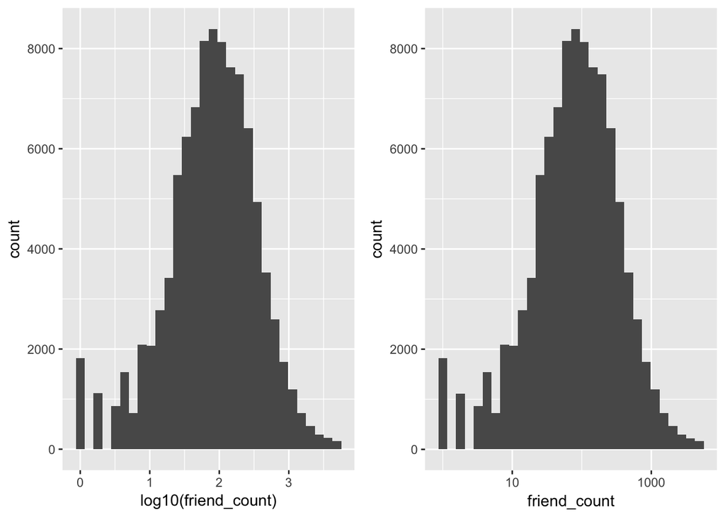

```r
# Two ways to transfer the variable:

# 1. used a wrapper right around the variable

logScale <- qplot(x = log10(friend_count), data = pf)

# 2. used a scaling layer
countScale <- ggplot(aes(x = friend_count), data = pf) +
  geom_histogram() +
  scale_x_log10()

grid.arrange(logScale, countScale, ncol = 2)
```

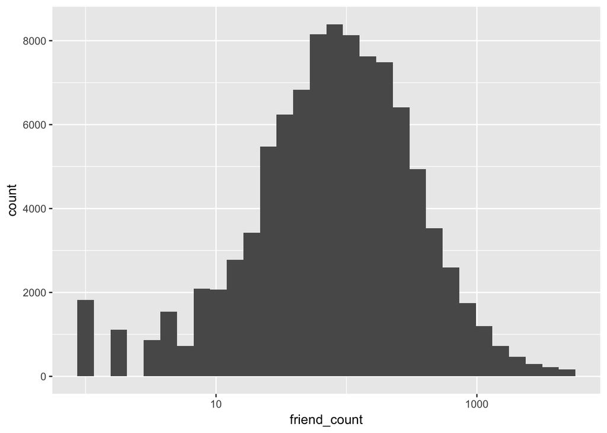

```r
# The difference between those two plots:
# -- using the log10 wrapper will label the x axis in log units where the layer will reflect the real numbers
ggplot(aes(x = friend_count), data = pf) +
  geom_histogram() +
  scale_x_log10()
```

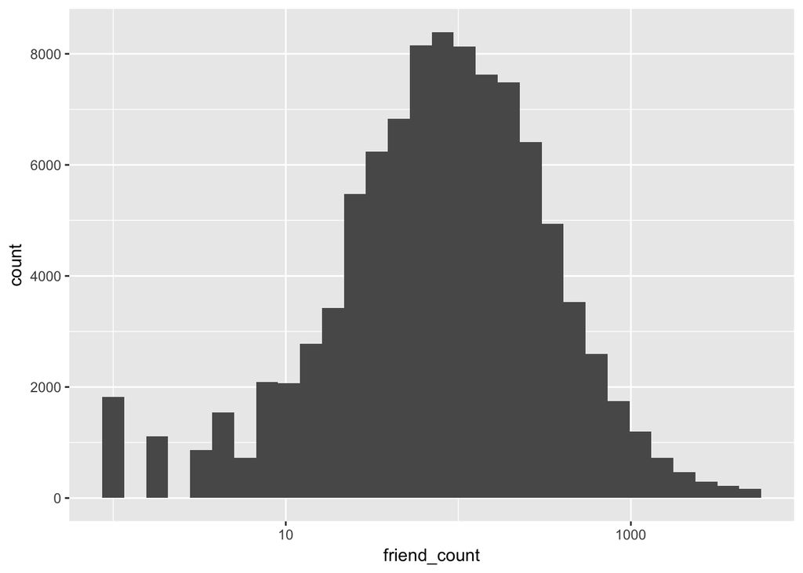

```r
# OR can do it in this way
qplot(x = friend_count, data = pf) +
  scale_x_log10()
```

### Frequency Polygons

- frequency polygons are similar to histograms, but draw a curve connecting the counts in a histogram.
- overlay these histograms together.

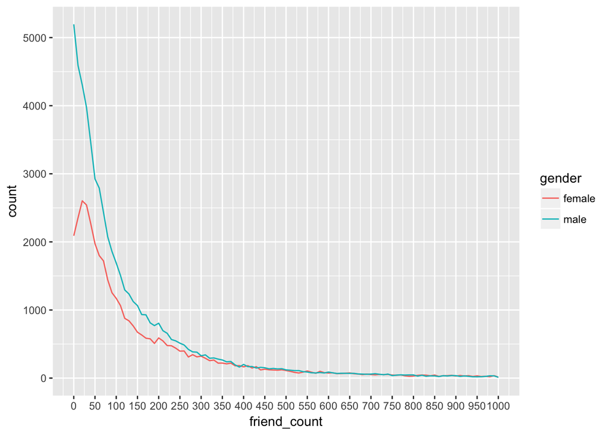

```r
qplot(x = friend_count, data = subset(pf, !is.na(gender)), binwidth = 10) +
  scale_x_continuous(lim = c(0, 1000), breaks = seq(0, 1000, 50)) +
facet_wrap(~gender)
qplot(x = friend_count, data = subset(pf, !is.na(gender)), binwidth = 10, geom = 'freqpoly', color = gender) +
  scale_x_continuous(lim = c(0, 1000), breaks = seq(0, 1000, 50))
```

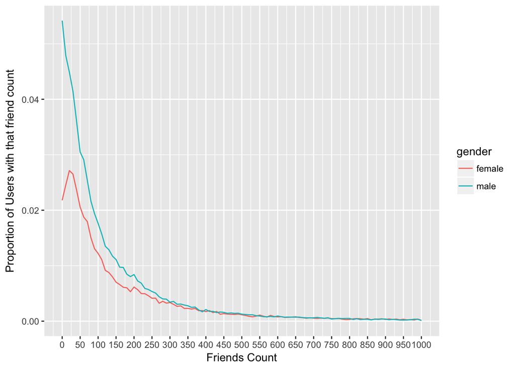

```r
qplot(x = friend_count, y = ..count../sum(..count..),
      data = subset(pf, !is.na(gender)),
      xlab = 'Friends Count',
      ylab = 'Proportion of Users with that friend count',
      binwidth = 10, geom = 'freqpoly', color = gender) +
  scale_x_continuous(lim = c(0, 1000), breaks = seq(0, 1000, 50))
```

### Likes on the Web

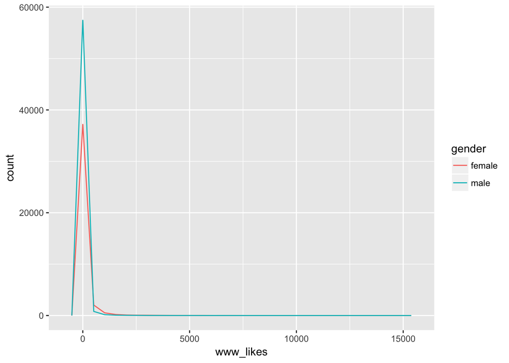

```r
qplot(x = www_likes, data = subset(pf, !is.na(gender)),
      geom = 'freqpoly', color = gender) +
  scale_x_continuous()
```

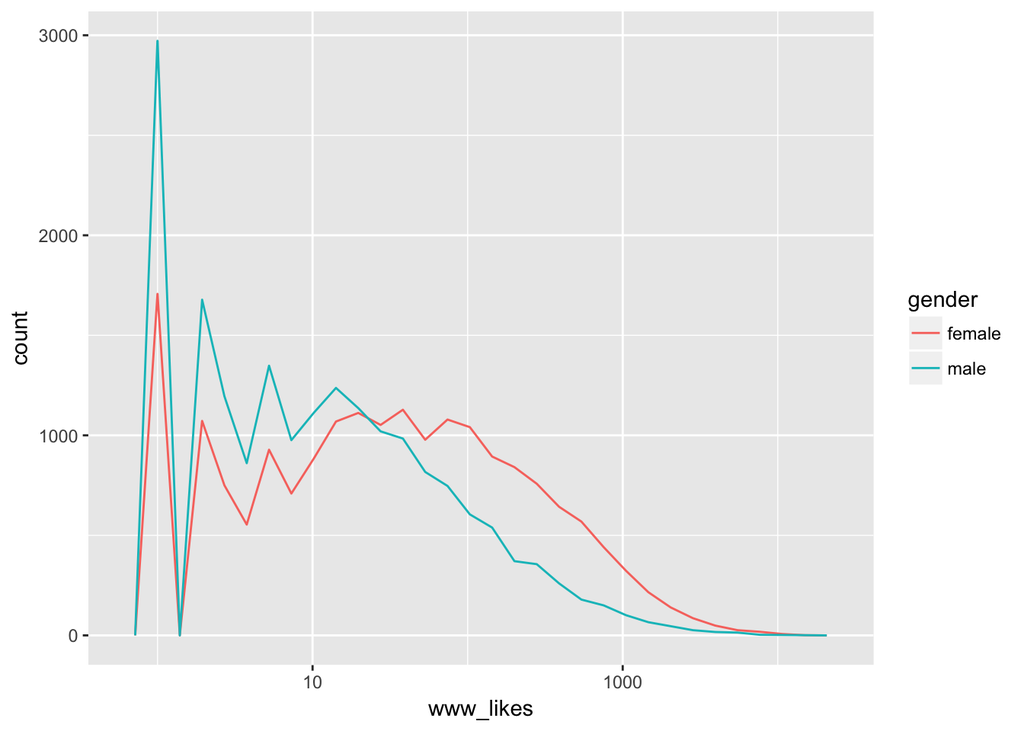

```r
# deal with long tail with log10 transform
qplot(x = www_likes, data = subset(pf, !is.na(gender)),
      geom = 'freqpoly', color = gender) +
  scale_x_continuous() +
  scale_x_log10()
```

```r
# Question: What's the www_like count for males? Which gender has more www_likes?

by(pf$www_likes, pf$gender, sum)  #  1430175 (male) < 3507665 (female)
```

```
## pf$gender: female
## [1] 3507665
## --------------------------------------------------------
## pf$gender: male
## [1] 1430175
```

### Box Plots

- another type of visualization for seeing the distribution of a variable
- the female’s median line seems slightly higher than males

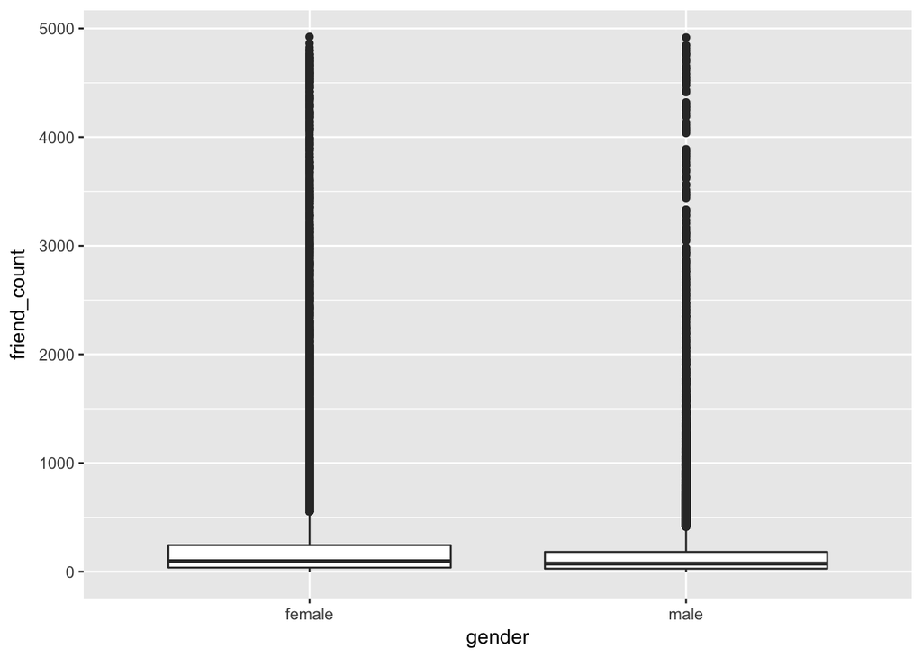

```r
qplot(x = gender, y = friend_count,
      data = subset(pf, !is.na(gender)),
      geom = 'boxplot')
```

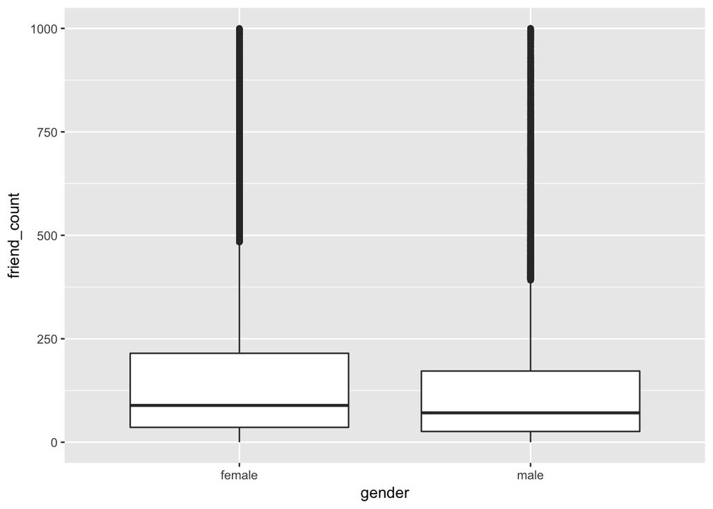

```r
# the horizontal line is the median for the two box plots
qplot(x = gender, y = friend_count,
      data = subset(pf, !is.na(gender)),
      geom = 'boxplot', ylim = c(0, 1000)) # Adjust the code to focus on users who have friend counts between 0 and 1000
```

### Box Plots, Quartiles, and Friendships

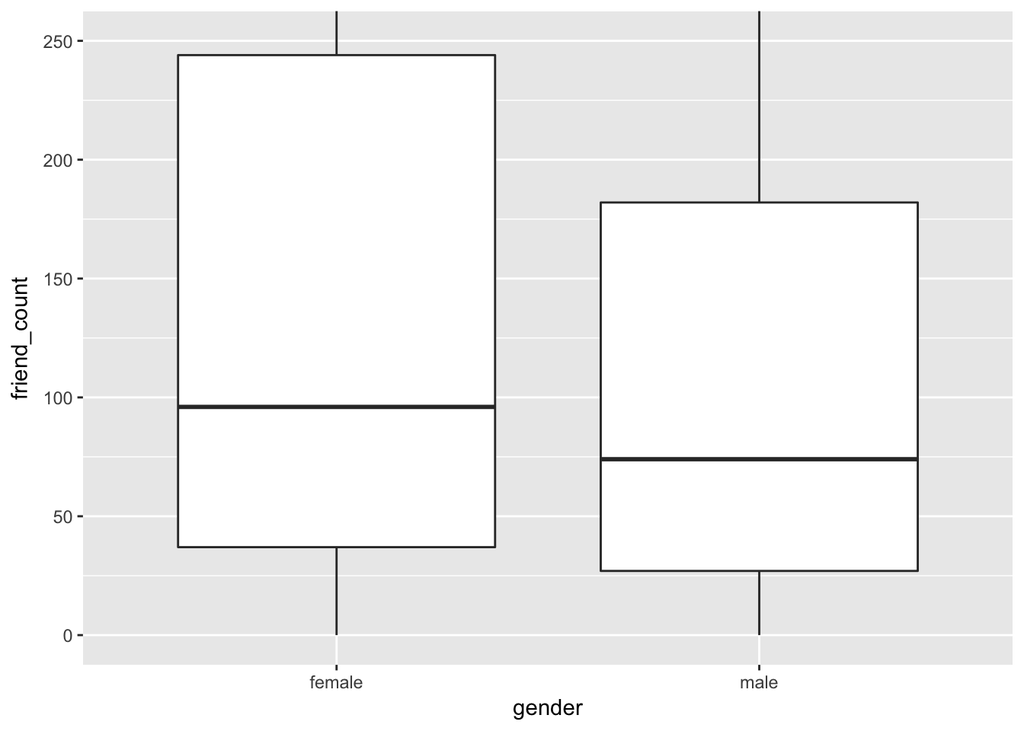

```r
qplot(x = gender, y = friend_count,
      data = subset(pf, !is.na(gender)),
      geom = 'boxplot') +
  coord_cartesian(ylim = c(0, 250))
```

```r
by(pf$friend_count, pf$gender, summary)
```

```
## pf$gender: female
##    Min. 1st Qu.  Median    Mean 3rd Qu.    Max.
##       0      37      96     242     244    4923
## --------------------------------------------------------
## pf$gender: male
##    Min. 1st Qu.  Median    Mean 3rd Qu.    Max.
##       0      27      74     165     182    4917
```

#### On average, who initiated more friendships in our sample: men or women?

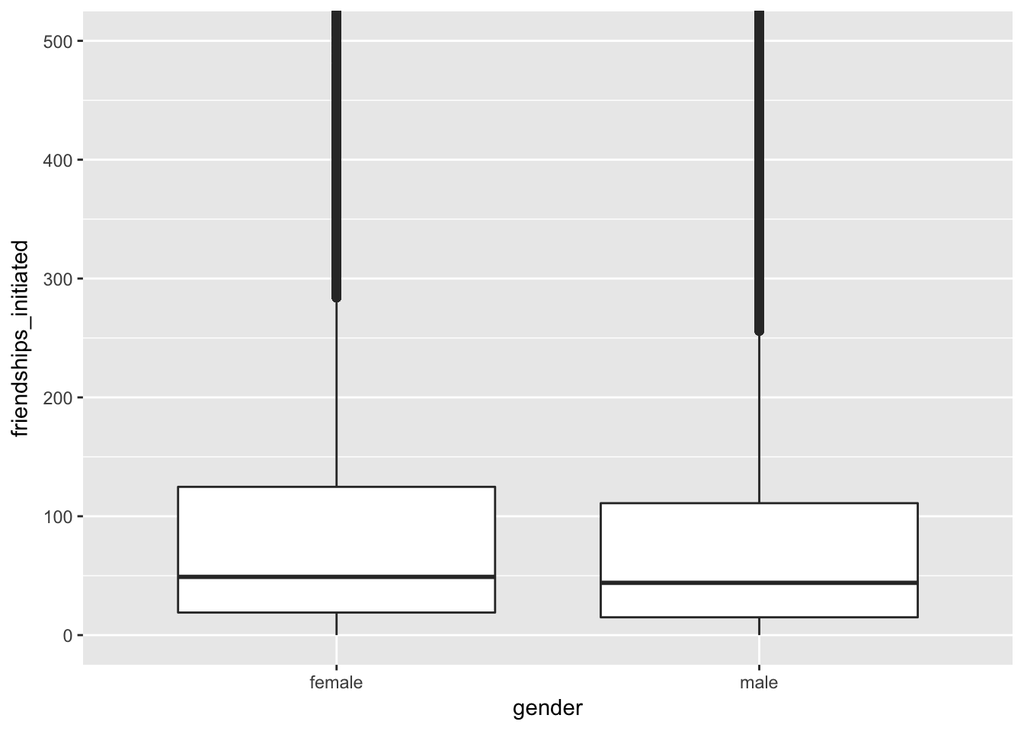

```r
qplot(x = gender, y = friendships_initiated,
      data = subset(pf, !is.na(gender)), geom = 'boxplot') +
  coord_cartesian(ylim = c(0, 500))
```

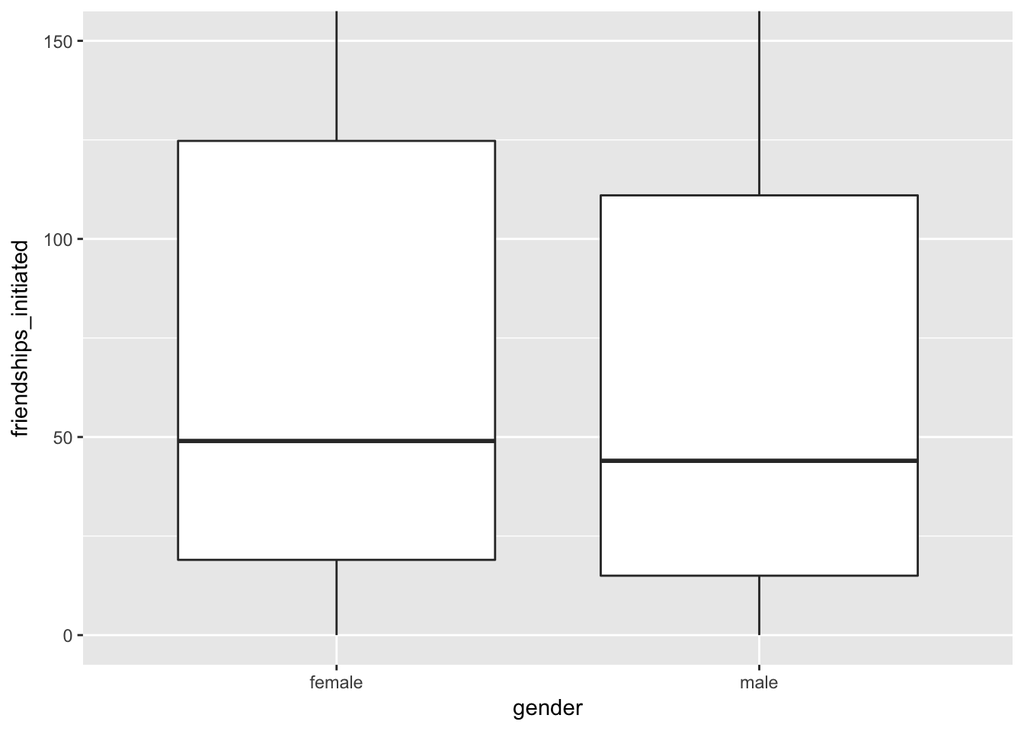

```r
# slightly higher them zoom in again
qplot(x = gender, y = friendships_initiated,
      data = subset(pf, !is.na(gender)), geom = 'boxplot') +
  coord_cartesian(ylim = c(0, 150))
```

```r
by(pf$friendships_initiated, pf$gender, summary)
```

```
## pf$gender: female
##    Min. 1st Qu.  Median    Mean 3rd Qu.    Max.
##     0.0    19.0    49.0   113.9   124.8  3654.0
## --------------------------------------------------------
## pf$gender: male
##    Min. 1st Qu.  Median    Mean 3rd Qu.    Max.
##     0.0    15.0    44.0   103.1   111.0  4144.0
```

### Getting Logical

- to a new binary variable that has only true or false

```r
summary(pf$mobile_likes)
```

```
##    Min. 1st Qu.  Median    Mean 3rd Qu.    Max.
##     0.0     0.0     4.0   106.1    46.0 25111.0
```

```r
summary(pf$mobile_likes > 0)
```

```
##    Mode   FALSE    TRUE
## logical   35056   63947
```

What percent of check in using mobile?

```r
mobile_check_in <- NA # create a new variable in the data frame with NA values
pf$mobile_check_in <- ifelse(pf$mobile_likes > 0, 1, 0)
pf$mobile_check_in <- factor(pf$mobile_check_in)
sum(pf$mobile_check_in == 1) / length(pf$mobile_check_in)
```

```
## [1] 0.6459097
```